# Statistical analysis

Author

Yendi E. Navarro-Noya and Luc Dendooven

All statistical analyses were done in R v. 4.5.0 (2025-04-11) (R Core Team et al. 2020) within the RStudio environment (Version 2025.05.0+496).

## Soil characteristics

A non-parametric test with the t1way function of the WRS2 package (library (WRS2)) (v. 1.1-7, (Mair 2020)) was used to determine the effect of the agricultural practices (pract) (permanent beds (PBR) versus conventional beds (CBR)) on the soil characteristics (soilchar). The WRS2 package has been described by its authors as “The t1way function computes a one-way ANOVA on trimmed means. Homoscedasticity assumption not required. It uses a generalization of Welch’s method. Corresponding post hoc tests can be performed using lincon.”

```r
library(WRS2)
t1way(pH ~ pract, data = soilchar)
lincon(pH ~ pract, data = soilchar)
```

“A heteroscedastic one-way ANOVA for trimmed means is a robust statistical test that compares group centers without assuming equal variances (heteroscedasticity) or normal distributions.”

## C and N mineralization

The effect of treatment (tre), i.e. soil amended with 300 mg NH4+ kg-1 or left unamended, and agricultural practices (pract) on the emission of CO2, soluble C, ammonium, nitrite, nitrate and mineral N on 3 and 14 days in base R was determined with t1way function in the WRS2 package, i.e. n = 3 (plots) and k = 4 (tre = 2 and pract = 2).

```r
library(WRS2)
t1way(Csol ~ pract, data = dynamics)
t1way(Csol ~ tre, data = dynamics)
```

## Availability raw sequences

The raw sequences dataset used in the subsequent analysis was deposited in the NCBI-SRA (Sequence Read Archive) under BioProject ID: PRJNA1164816 and Submission ID: SUB14679678.

## Alpha diversity

Alpha diversity of soil archaeal and bacterial community was determined based on the Hill numbers at different q orders (q = 0, 1 and 2) (Chao, Chiu, and Jost 2010). The Hill number at q = 0 gives the species richness, q = 1 is the Shannon entropy and denotes frequently occurring species and q = 2 is the inverse Simpson and characterizes dominant species (Chao, Chiu, and Jost 2014). They were calculated with the HillR package v. 0.5.2 (Li, 2023).

```r
library(hillR)
hill_taxa(sequences, q=0)
hill_taxa(sequences, q=1)
hill_taxa(sequences, q=2)
```

Boxplots were generated with the Hill numbers:

```r
library(hillR)
Boxplot (q0 ~ code, data = Hill, main="Hill number at q=0")
Boxplot (q1 ~ code, data = Hill, main="Hill number at q=1")
Boxplot (q2 ~ code, data = Hill, main="Hill number at q=2")
```

A non-parametric analysis (t1way test of the WRS2 package, v. 1.1-7, (Mair 2020)) was used to determine the effect of agricultural practices (pract CBR vs PBR) and ammonium application (tre) on the Hill numbers.

```r
library(hillR)
t1way(q0 ~ pract, data = dynamics)
t1way(q0 ~ tre, data = dynamics)
```

## Beta diversity

### Principal component analysis

Ordination (principal component analysis, PCA) and multivariate comparison (perMANOVA, (Anderson 2014)) were done with converted sequence data using the centered log-ratio transformation test returned by the aldex.clr function ALDEx2 (v. 1.40.0) (G. B. Gloor et al. 2017) (G. Gloor et al. 2020). The ALDEx2 package was described by its authors as: “Analysis Of Differential Abundance Taking Sample and Scale Variation Into Account”

```r
Library (ALDEx2)
x <- aldex.clr(sequences, mc.samples = 999, denom="all", verbose = FALSE, useMC=FALSE)
getMonteCarloSample(x,1)
clrseq <- getMonteCarloSample(x,1)
```

The FactoMineR (v. 2.3) package (Husson et al. 2020) was used for the PCA.

```r
Library (FactoMineR)
set.seed (123)
sequences.pca <- PCA(clrseq, scale.unit=FALSE)
#coordinates of the treatment
print(sequences.pca$var$coord)
sequencesv <- sequences.pca$var$coord
write.table(sequencesv, "PCABgv", sep="\t")
#coordinates of the groups considered
print(seq.pca$ind$coord)
sequencesi <- sequences.pca$ind$coord
write.table(sequencesi, "PCABgi", sep="\t")
#plot PCA
plot(seq.pca, axes = c(1, 2), cex=0.8)
```

Figures were made in Microsoft® Excel for Mac.

### PERMANOVA

The vegan (v. 2.7-0) package was used for the multivariate comparison (PERMANOVA (Anderson 2014) (Oksanen et al. 2013)). The vegan package was described by its authors as: “Ordination methods, diversity analysis and other functions for community and vegetation ecologists.”

Centered log-ratio transformed data were used, obtained by aldex.clr function ALDEx2 (v. 1.40.0) (G. B. Gloor et al. 2017) (G. Gloor et al. 2020).

```r
library(vegan)
set.seed(123)
perm<- how(nperm=999)
setBlocks(perm) <- with(code, plot)
adonis2(clrseq ~ pract, data=code, permutations=999, method = "euclidean")
adonis2(clrseq ~ tre, data=code, permutations=999, method = "euclidean")
```

### Dispersion

The vegan (v. 2.7-0) package was used to determine the homogeneity of groups dispersions, i.e. dispersion within the ammonium and unamended soil or between the CBR and PBR (Anderson 2014) (Oksanen et al. 2013). This test was applied only when a pairwise comparison (perMANOVA) resulted in a significant effect.

```r
library(vegan)
set.seed(123)
groups <- factor(c(rep(1,3),rep(2,3)), labels = c("A", "B"))
dis <- vegdist(clrseq, method = "euclidean")
mod <- betadisper(dis, groups)
anova(mod)
TukeyHSD(mod)
plot(mod)
adonis2(clrseq ~ groups, perm=999)
permutest(mod,permutations =999)
permutest(mod, pairwise = TRUE, permutations =999)
TukeyHSD(mod)
```

### Effect size

The effect size, which is defined as the difference between groups divided by the maximum dispersion within group A or B, was calculated after a centered log-ratio transformation with the aldex.ttest argument (ALDEx2 (version, 1.18), (G. Gloor et al. 2020). The effect size was calculated comparing the bacterial, archaeal, fungal, AOB, NOB and AOA species, and the genes and the genes involved in the N cycle in the unamended versus the ammonium amended soil and the CBR treatment versus the PBR treatment after 3 and 14 days. The effect sizes of each comparison were plotted in Microsoft Excel for Mac v. 16.62.

```r
library(ALDEx2)
conds <- c(rep("A", 3), rep("B", 3))
x.clr <- aldex.clr(clrseq, conds, mc.samples=128, denom="all",verbose=FALSE, useMC=FALSE)
effect.test.Practice=aldex.effect(x.clr, useMC = T)
ttest.Practice=aldex.ttest(x.clr)
Effect_ttest.Practice=cbind(effect.test.Practice, ttest.Practice)
write.table(Effect_ttest.Practice, "effect_test_Practice.txt", sep="\t")
x.kw <- aldex.kw(x.clr)
View(x.kw)
write.table(x.kw, "sub", sep="\t")
```

Vulcano plots can be generated by plotting the effect size versus the p value.

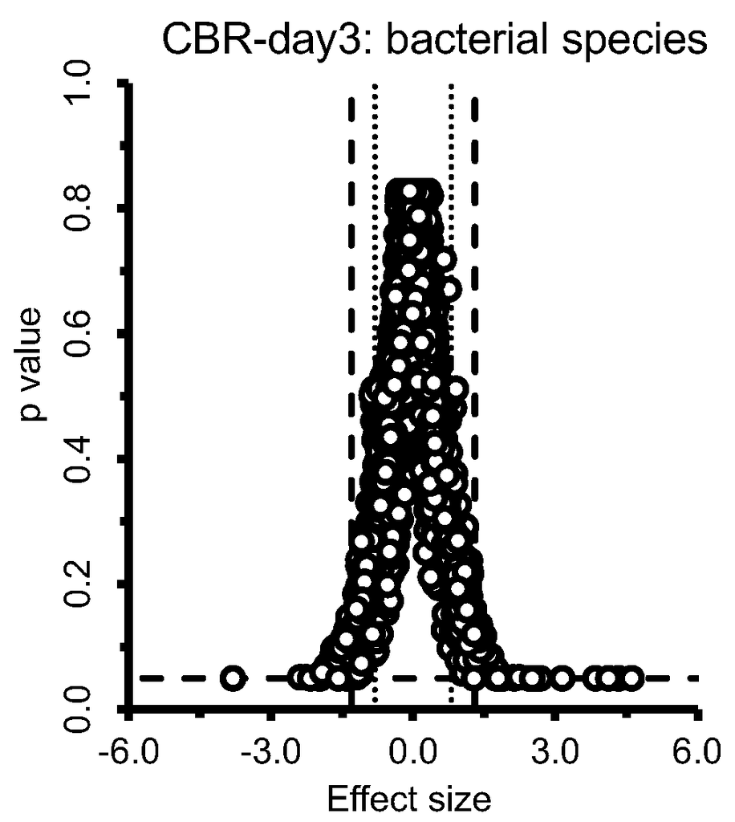

However, to avoid overloading the manuscript, only effect sizes were given per sample. As such, the “spread” of the effect sizes of the different microorganism studied were visualized per sample. Additionally, the mean of the absolute effects sizes was computed to compare the effect of NH4+ application and agricultural practices on the microbial groups. These values were given in the corresponding figures.

## References

Anderson, Marti J. 2014. “Permutational Multivariate Analysis of Variance (PERMANOVA).” *Wiley Statsref: Statistics Reference Online*, 1–15.

Chao, Anne, Chun-Huo Chiu, and Lou Jost. 2010. “Phylogenetic Diversity Measures Based on Hill Numbers.” *Philosophical Transactions of the Royal Society B: Biological Sciences* 365 (1558): 3599–609.

———. 2014. “Unifying Species Diversity, Phylogenetic Diversity, Functional Diversity, and Related Similarity and Differentiation Measures Through Hill Numbers.” *Annual Review of Ecology, Evolution, and Systematics* 45 (1): 297–324.

Gloor, G, A Fernandes, J Macklain, A Albert, M Links, T Quinn, JR Wu, RG Wong, and B Lieng. 2020. “ALDEx2 Package: Analysis of Differential Abundance Taking Sample Variation into Account. Version: 1.21. 1.” In *ALDEx2 Package: Analysis of Differential Abundance Taking Sample Variation into Account. Version: 1.21. 1*.

Gloor, Gregory B, Jean M Macklaim, Vera Pawlowsky-Glahn, and Juan J Egozcue. 2017. “Microbiome Datasets Are Compositional: And This Is Not Optional.” *Frontiers in Microbiology* 8: 2224.

Husson, F, J Josse, S Le, and J Mazet. 2020. “FactoMineR Package: Multivariate Exploratory Analysis and Data Mining. Version: 2.3.”

Mair, P. 2020. “WRS2: A Collection of Robust Statistical Methods Based on Wilcox’WRS Functions. Version: 1.1–0.”

Oksanen, Jari, F Guillaume Blanchet, Roeland Kindt, Pierre Legendre, Peter R Minchin, RB O’hara, Gavin L Simpson, et al. 2013. “Package ‘Vegan’.” *Community Ecology Package, Version* 2 (9): 1–295.

R Core Team, R et al. 2020. “R: A Language and Environment for Statistical Computing.” Citeseer.